# Data_visualization(I)

Author

Setareh

Published

November 24, 2025

## R info

```
R version: R version 4.4.1 (2024-06-14 ucrt)
```

```
Operating system: Windows 11 x64 (build 22631)
```

# Libraries need to be installed and loaded

```r
rm(list = ls())
knitr::opts_chunk$set(echo = FALSE, warning = FALSE, message = FALSE)
library(ggplot2)
library(dplyr)
library(MPsychoR) # for two data set on IQ and
library(kableExtra)
library(ggpubr)
library(scatterplot3d)
library(GGally)
```

# Anscombe’s quartet example

Anscombe (1973) simulated Four data sets with identical descriptive statistics, they are available in R:

```
       x1             x2             x3             x4           y1
 Min.   : 4.0   Min.   : 4.0   Min.   : 4.0   Min.   : 8   Min.   : 4.260
 1st Qu.: 6.5   1st Qu.: 6.5   1st Qu.: 6.5   1st Qu.: 8   1st Qu.: 6.315
 Median : 9.0   Median : 9.0   Median : 9.0   Median : 8   Median : 7.580
 Mean   : 9.0   Mean   : 9.0   Mean   : 9.0   Mean   : 9   Mean   : 7.501
 3rd Qu.:11.5   3rd Qu.:11.5   3rd Qu.:11.5   3rd Qu.: 8   3rd Qu.: 8.570
 Max.   :14.0   Max.   :14.0   Max.   :14.0   Max.   :19   Max.   :10.840
       y2              y3              y4
 Min.   :3.100   Min.   : 5.39   Min.   : 5.250
 1st Qu.:6.695   1st Qu.: 6.25   1st Qu.: 6.170
 Median :8.140   Median : 7.11   Median : 7.040
 Mean   :7.501   Mean   : 7.50   Mean   : 7.501
 3rd Qu.:8.950   3rd Qu.: 7.98   3rd Qu.: 8.190
 Max.   :9.260   Max.   :12.74   Max.   :12.500
```

## Only graphical presentation could reveal the differences:

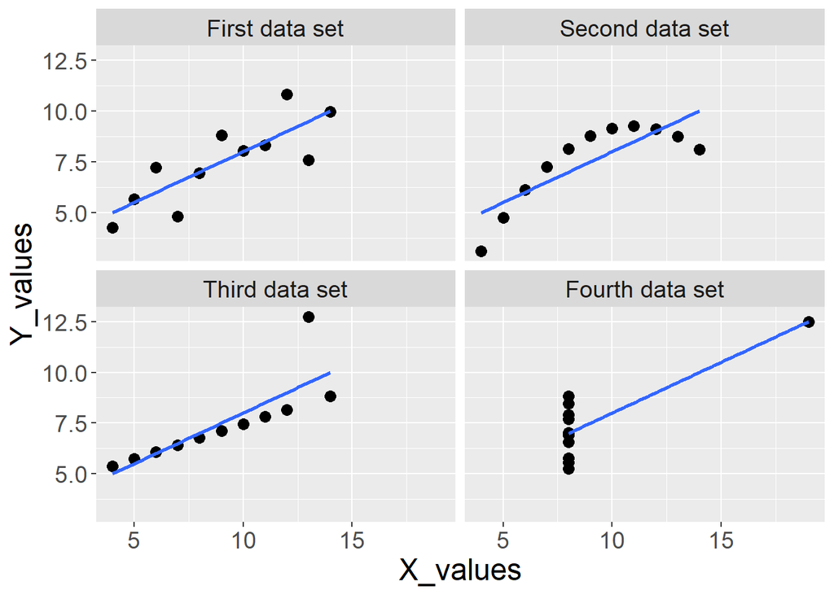

```r
p <- ggplot(data, aes(x=x, y=y))+geom_point(size=3)+geom_smooth(method = "lm", se=FALSE)

# make separate plots for each dataset
p + facet_wrap(~factor(group,levels=c("First data set","Second data set","Third data set","Fourth data set"))) +xlab("X_values")+ylab("Y_values")+ theme(text=element_text(size=18, family="Serif"))
```

This is how you can use the ggplot package the most powerful package for visualization in R . To get familiar with the elements of ggplot and how it work you can consult many online sources such as : [Introduction to ggplot](http://euclid.psych.yorku.ca/www/psy6135/lectures/ggplot-intro.pdf).

## Another example: Jan Vanhove(2016):

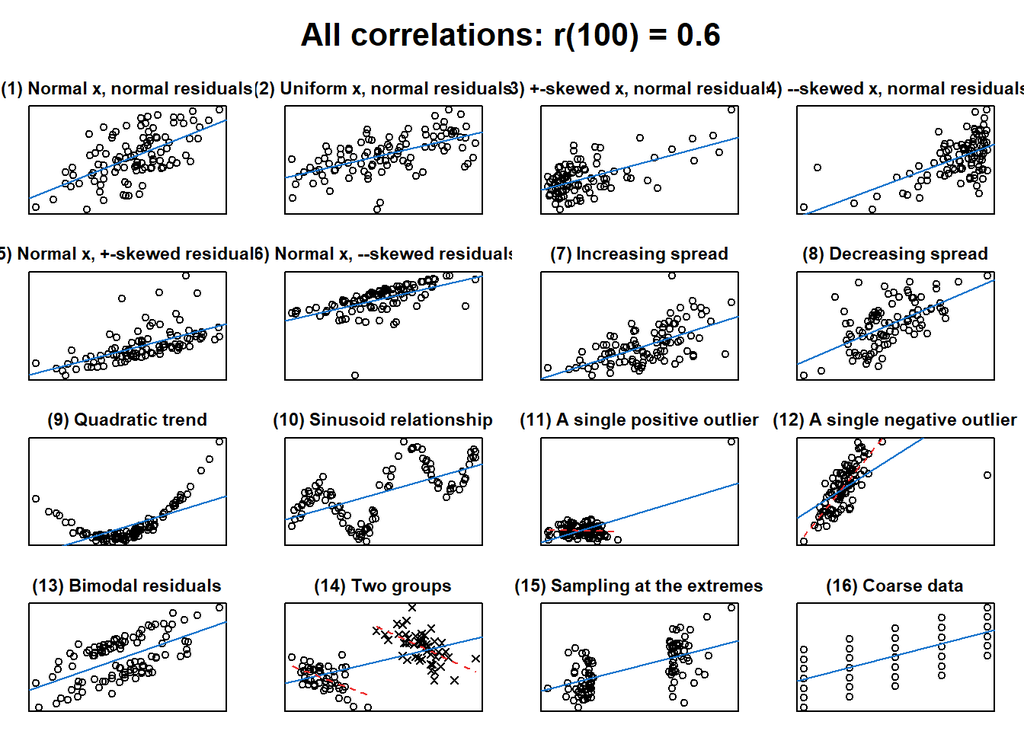

```r
source("http://janhove.github.io/RCode/plot_r.R")
plot_r(r=0.6, n=100, showdata = F)
```

# Univariate graphs

## Categorical data

### About the dataset:

Haegeli et al. (2012) studied high-risk cohorts in a complex and dynamic risk environment. This dataset contains four variables related to preparedness before going for country skiing. The variables with response categories are 1) check avalanche danger information (check conditions on internet prior to leaving home; talk to ski patrol; check postings at gates or information kiosks at resort; do not check or Do not know), 2) discuss avalanche hazard in your group (all the time; 50% to 90% of time; 10% to 40% of time; never or solo traveler), 3) approach to decision making (dedicated leader or everybody contributes; person in front decides; everybody makes their own choices or solo traveler), and 4) use of avalanche safety gear (everybody carries beacon, shovel and probe; everybody carries beacon or beacon and shovel; some in group carry beacons; some in group have cell phones; no safety equipment is carried). The data is in the package “MpsychoR” use the following to load the data:

```r
library(MPsychoR)
data("AvalanchePrep")


AvalanchePrep$info <- factor(AvalanchePrep$info, labels=c("Internet","Others","Gate"," No check"))

AvalanchePrep$discuss <- factor(AvalanchePrep$discuss, labels=c("all_time", "50%_90%", "10%_40%", "never"))

AvalanchePrep$gear <- factor(AvalanchePrep$gear, labels=c("beacon and shovel", "beacon or shovel", "some-beacons","some-cell phones", "no safety"))

AvalanchePrep$decision <- factor(AvalanchePrep$decision, labels=c("dedicated leader", "front person ", "own_choices"))
```

Look at the summary of your data, you can see what variables are in your data set and what type they are:

```
        info          discuss                   gear
 Internet :1279   all_time:639   beacon and shovel:910
 Others   :  36   50%_90% :597   beacon or shovel : 96
 Gate     :  18   10%_40% : 62   some-beacons     :118
  No check:  22   never   : 57   some-cell phones :135
                                 no safety        : 96
             decision
 dedicated leader:1252
 front person    :  10
 own_choices     :  93
```

### Bar Plot

```r
# Codes from ChatGPT
# Assuming `discuss` is a categorical variable in your dataset
# Replace `your_data` with the actual dataset name
ggplot(AvalanchePrep, aes(x = info)) +
  geom_bar(fill = "skyblue") +
  labs(title = "Distribution of Discuss Variable",
       x = "Discuss Avalanche Preparedness",
       y = "Frequency") +
  theme_minimal()
```

[figure not shown]

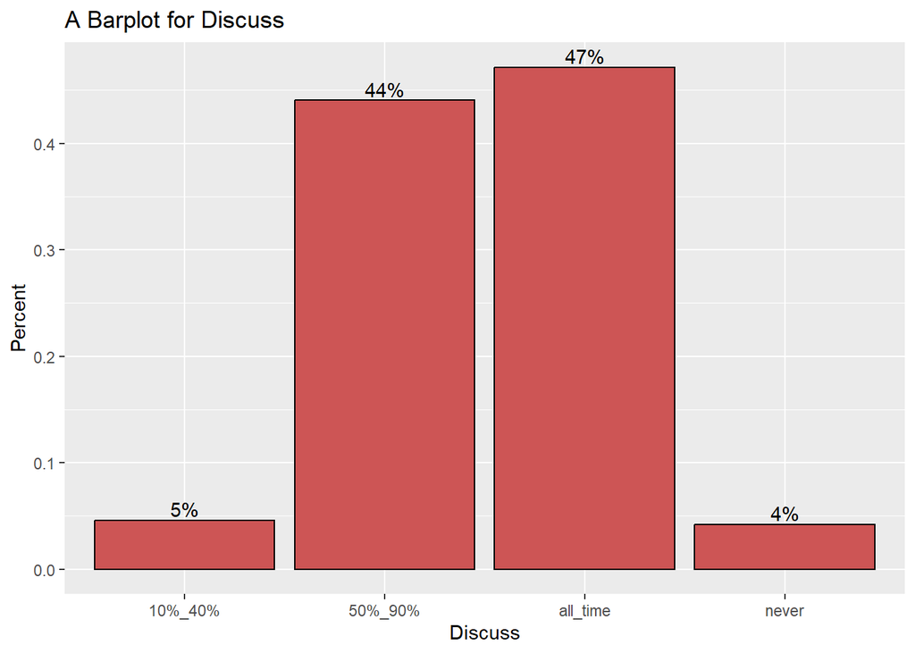

```r
# For categorical variable Discuss calculate the percentage of each level
plotdata <- AvalanchePrep %>%
  count(discuss) %>%
  mutate(pct = n / sum(n),
         pctlabel = paste0(round(pct*100), "%"),
         diss_categories = c("all_time", "50%_90%", "10%_40%", "never"))

# plot the bars as percentages,
ggplot(plotdata,
       aes(x = diss_categories, y = pct)) +
  geom_bar(stat="identity", fill="indianred3", color="black") +
  geom_text(aes(label = pctlabel), vjust=-0.25) +
    labs(x = "Discuss",
       y = "Percent",
       title  = "A Barplot for Discuss")
```

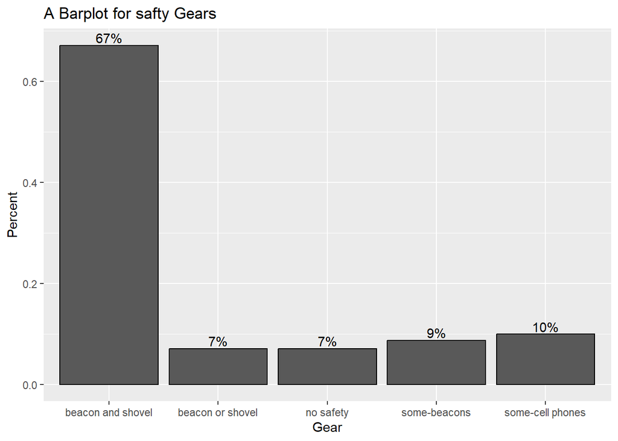

```r
# For categorical variable Gear calculate the percentage of each level
plotdata <- AvalanchePrep %>%
  count(gear) %>%
  mutate(pct = n / sum(n),
         pctlabel = paste0(round(pct*100), "%"),
         gear_categories = c("beacon and shovel", "beacon or shovel", "some-beacons","some-cell phones", "no safety"))

# plot the bars as percentages,
ggplot(plotdata,
       aes(x = gear_categories, y = pct)) +
  geom_bar(stat="identity", color="black") +
  geom_text(aes(label = pctlabel), vjust=-0.25) +
    labs(x = "Gear",
       y = "Percent",
       title  = "A Barplot for safty Gears")
```

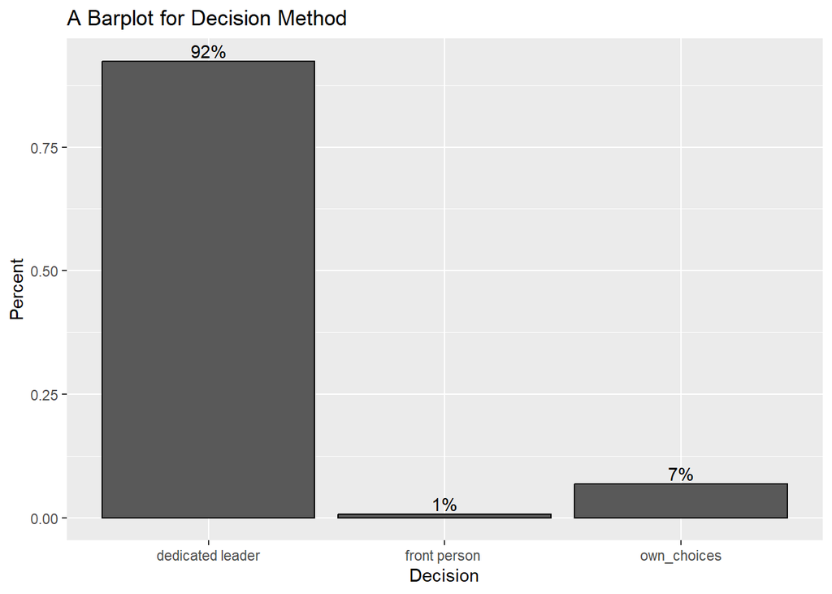

```r
# For categorical variable Decission  calculate the percentage of each level
plotdata <- AvalanchePrep %>%
  count(decision) %>%
  mutate(pct = n / sum(n),
         pctlabel = paste0(round(pct*100), "%"),
         dec_categories = c("dedicated leader", "front person ", "own_choices"))

# plot the bars as percentages,
ggplot(plotdata,
       aes(x = dec_categories, y = pct)) +
  geom_bar(stat="identity", color="black") +
  geom_text(aes(label = pctlabel), vjust=-0.25) +
    labs(x = "Decision",
       y = "Percent",
       title  = "A Barplot for Decision Method")
```

### Reordering and turning the axis and bar chart

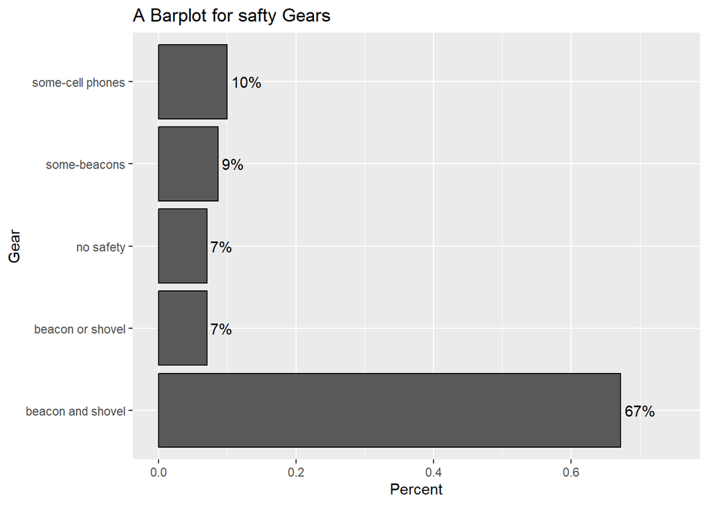

```r
# For categorical variable Gear calculate the percentage of each level
plotdata <- AvalanchePrep %>%
  count(gear) %>%
  mutate(pct = n / sum(n),
         pctlabel = paste0(round(pct*100), "%"),
         gear_categories = c("beacon and shovel", "beacon or shovel", "some-beacons","some-cell phones", "no safety"))

# plot the bars as percentages,
ggplot(plotdata,
       aes(x = gear_categories, y = pct)) +
  geom_bar(stat="identity", color="black") +
  geom_text(aes(label = pctlabel), hjust=-0.15) +ylim(c(0,0.75))+
    labs(x = "Gear",
       y = "Percent",
       title  = "A Barplot for safty Gears")+
  coord_flip()
```

- Alternatively, you can rotate the axis labels:

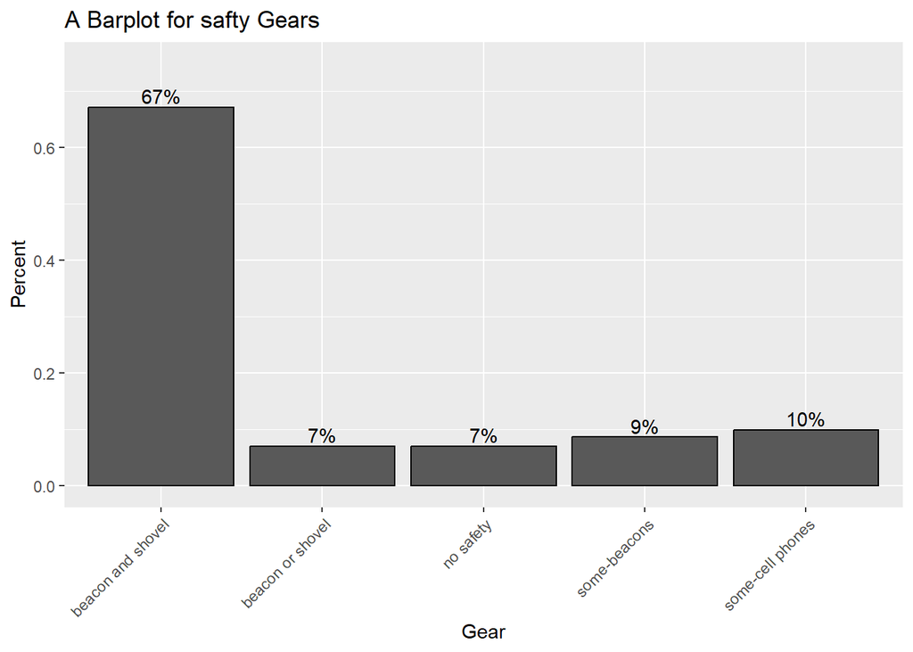

```r
# For categorical variable Gear calculate the percentage of each level
plotdata <- AvalanchePrep %>%
  count(gear) %>%
  mutate(pct = n / sum(n),
         pctlabel = paste0(round(pct*100), "%"),
         gear_categories = c("beacon and shovel", "beacon or shovel", "some-beacons","some-cell phones", "no safety"))

# plot the bars as percentages,
ggplot(plotdata,
       aes(x = gear_categories, y = pct)) +
  geom_bar(stat="identity", color="black") +
  geom_text(aes(label = pctlabel), vjust=-0.25) +ylim(c(0,0.75))+
    labs(x = "Gear",
       y = "Percent",
       title  = "A Barplot for safty Gears")+
theme(axis.text.x = element_text(angle = 45,
                                   hjust = 1))
```

### Sort the bars by frequencies

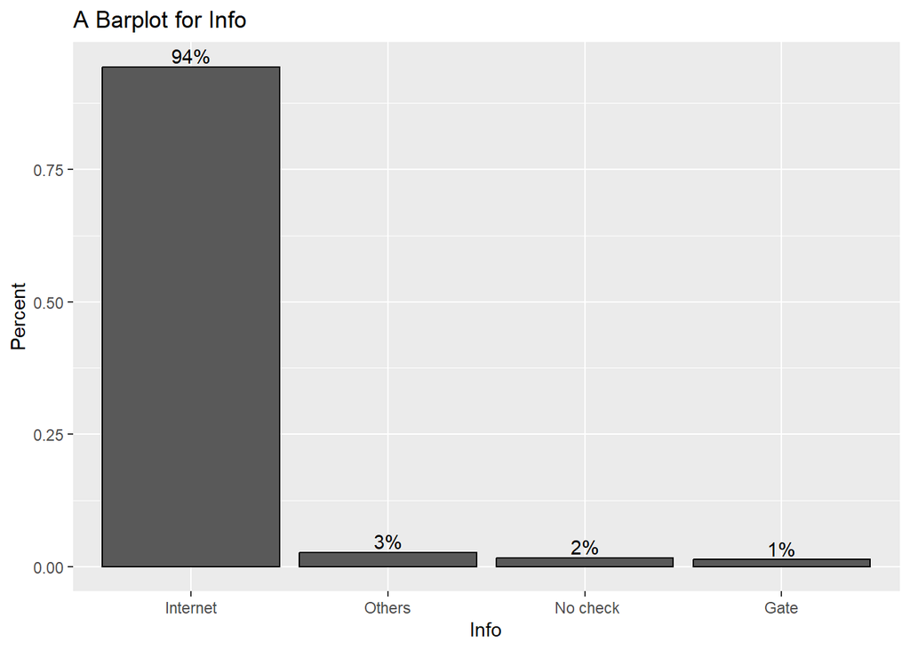

```r
# For categorical variable info calculate the percentage of each level
plotdata <- AvalanchePrep %>%
  count(info) %>%
  mutate(pct = n / sum(n),
         pctlabel = paste0(round(pct*100), "%"),
         info_categories = c("Internet","Others","Gate"," No check"))

# plot the bars as percentages,
ggplot(plotdata,
       aes(x = reorder(info_categories,-pct), y = pct)) +
  geom_bar(stat="identity", color="black") +
  geom_text(aes(label = pctlabel), vjust=-0.25) +
    labs(x = "Info",
       y = "Percent",
       title  = "A Barplot for Info")
```

### Pie Charts

Bar charts are preferred to the pie chart is the aim is to compare the categories. Pie charts are used mainly when the goal is see the percentage of each category with the whole.

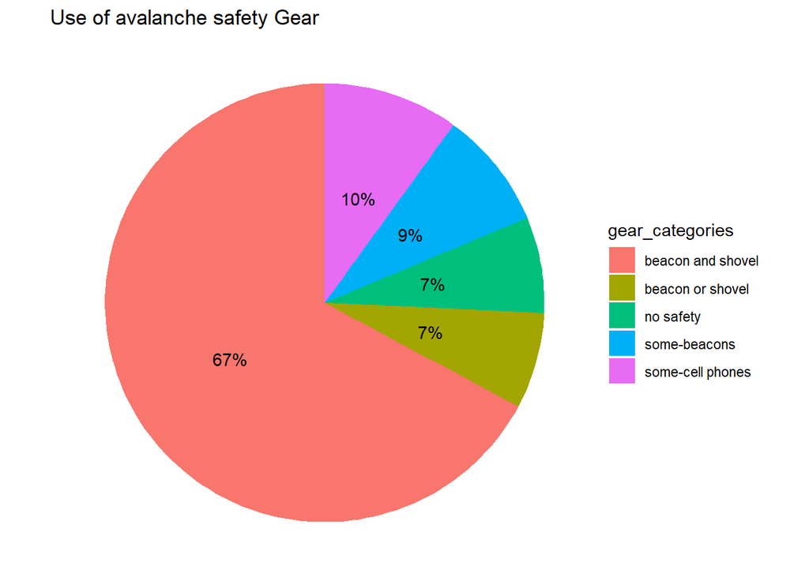

```r
# For categorical variable info calculate the percentage of each level
plotdata <- AvalanchePrep %>%
  count(gear) %>%
  mutate(pct = n / sum(n),
         pctlabel = paste0(round(pct*100), "%"),
         gear_categories = c("beacon and shovel", "beacon or shovel", "some-beacons","some-cell phones", "no safety"))

# plot the bars as percentages,
ggplot(plotdata,
       aes(x = "", y = pct, fill = gear_categories)) +
  geom_bar(stat = "identity") +
  geom_text(aes(label = pctlabel),
            position = position_stack(vjust = 0.5)) +
  coord_polar("y") +
  theme_void()+ggtitle("")+ggtitle("Use of avalanche safety Gear")
```

### Polar coordinate Bar-chart

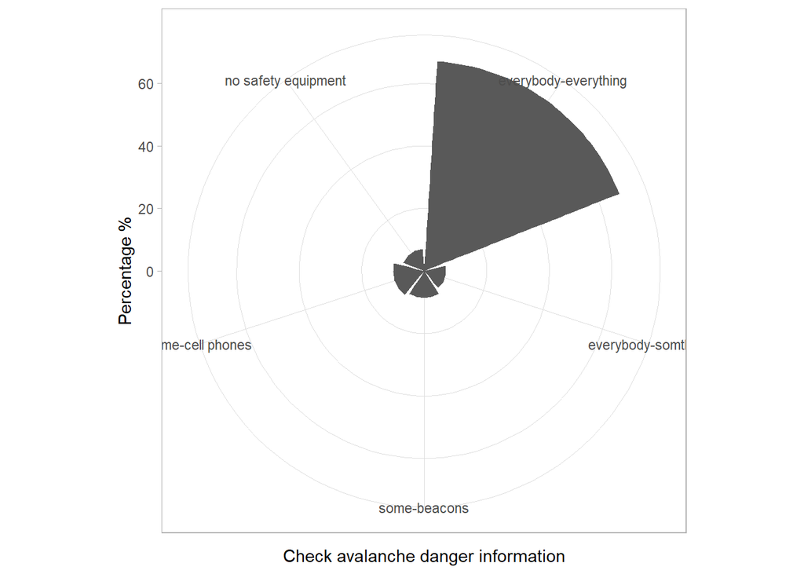

```r
ggplot(AvalanchePrep)+geom_bar(aes(x=gear, y=stat(prop)*100,group=1)) + ylab("Percentage %")+ xlab("Check avalanche danger information")+ theme_light()+coord_polar()+scale_x_discrete(labels=c("everybody-everything", "everybody-somthing", "some-beacons","some-cell phones", "no safety equipment"))
```

## Quantitative data

### About granularity dataset:

Granularity refers to a person’s ability to separate their emotions into specific types. People with low granularity struggle to separate their emotions (e.g., reporting that sadness, anger, fear, and others all just feel “bad”“), whereas people with high granularity are very specific in how they parse their emotions (e.g., easily distinguishing between nuanced emotions like disappointment and frustration). A few outliers were removed compared to the original data.

```r
data("granularity")
```

### Histogram of Age

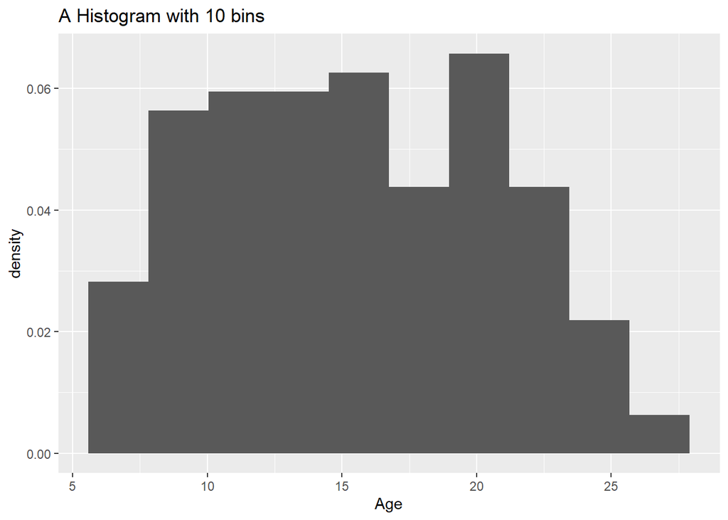

```r
hist_age<- ggplot(granularity)+geom_histogram(aes(x=age,y=..density..),bins = 10)+xlab("Age")+ggtitle("A Histogram with 10 bins")
hist_age
```

### binwidth and bin

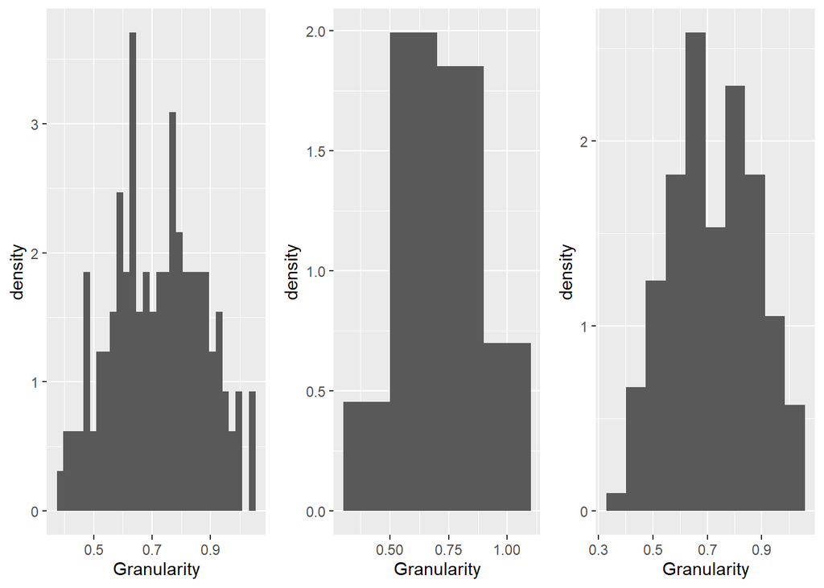

```r
hist_gran1 <- ggplot(granularity)+geom_histogram(aes(x=gran,y=..density..))+xlab("Granularity")
hist_gran2 <- ggplot(granularity)+geom_histogram(aes(x=gran,y=..density..),binwidth = 0.2)+xlab("Granularity")
hist_gran3 <- ggplot(granularity)+geom_histogram(aes(x=gran,y=..density..),bins = 10)+xlab("Granularity")
ggarrange(hist_gran1,hist_gran2,hist_gran3,nrow=1)
```

### Kernel density

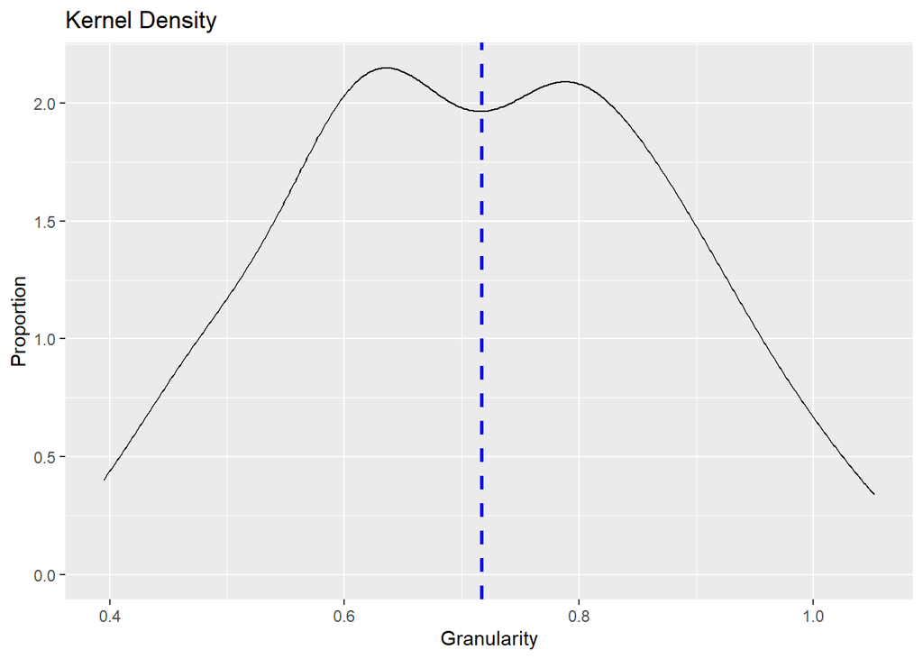

```r
# Kernel density with the vertical line at mean
ggplot(granularity,aes(x=gran))+geom_density()+xlab("Granularity")+ylab("Proportion")+ggtitle("Kernel Density")+ geom_vline(aes(xintercept=mean(gran)),
            color="blue", linetype="dashed", size=1)
```

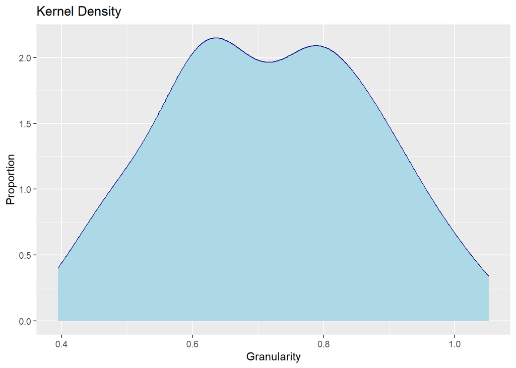

```r
# Coloring fill of kernel density
ggplot(granularity,aes(x=gran))+geom_density(color="darkblue", fill="lightblue")+xlab("Granularity")+ylab("Proportion")+ggtitle("Kernel Density")
```

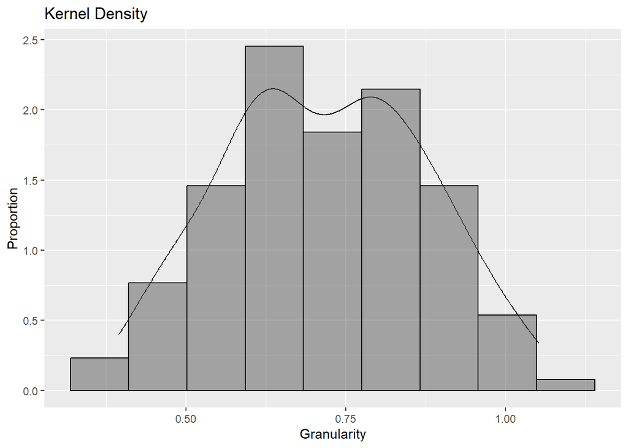

```r
# Superpose kernel density and histogram with optimum bin_width
ggplot(granularity)+geom_density(aes(x=gran))+geom_histogram(aes(x=gran,y=..density..),binwidth = function(x) 2 * IQR(x) / (length(x)^(1/3)),alpha=0.5,color="black")+xlab("Granularity")+ylab("Proportion")+ggtitle("Kernel Density")
```

### Dotplot

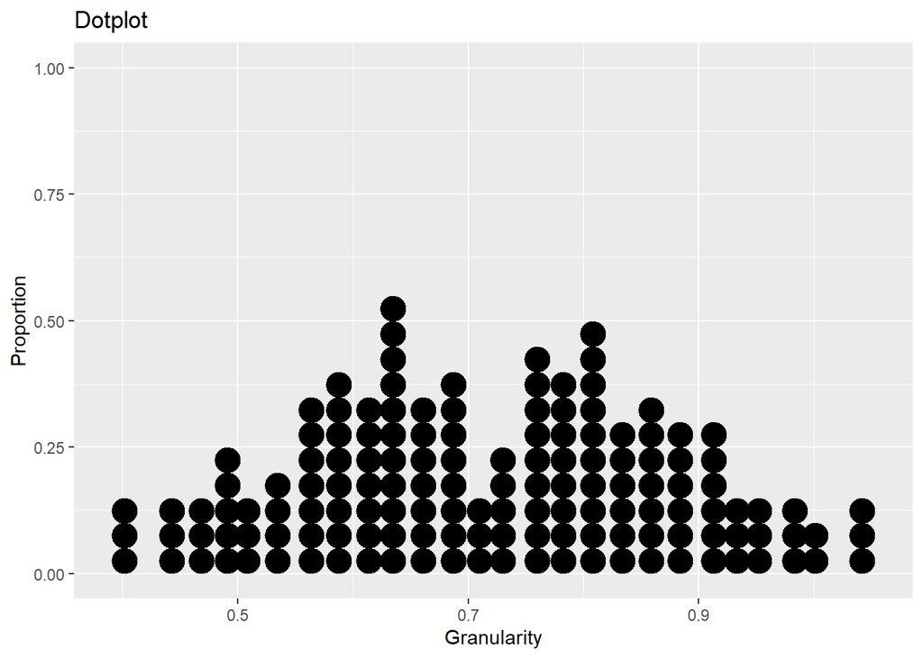

```r
ggplot(granularity)+geom_dotplot(aes(x=gran))+xlab("Granularity")+ylab("Proportion")+ggtitle("Dotplot")
```

### Boxplot

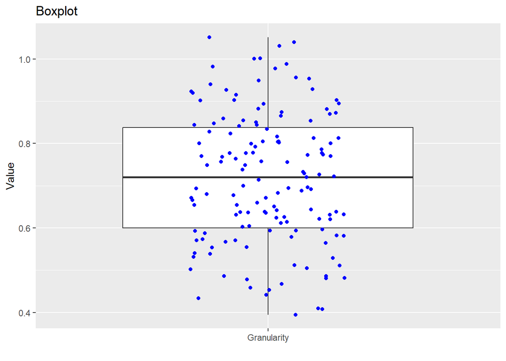

```r
ggplot(granularity,aes(y=gran,x="Granularity"))+geom_boxplot(outlier.colour ="red")+geom_jitter(color="blue",height = 0,width = 0.2)+ xlab("")+ylab("Value")+ggtitle("Boxplot")
```

### Violon Plot

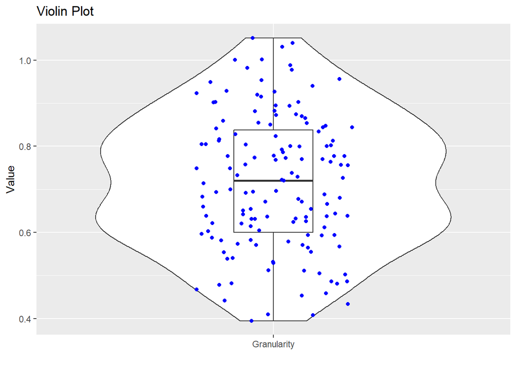

```r
ggplot(granularity,aes(y=gran,x="Granularity"))+geom_violin()+ geom_boxplot(width=0.2) + geom_jitter(color="blue",height = 0,width = 0.2)+ xlab("")+ylab("Value")+ggtitle("Violin Plot")
```

# Bivariate graphs

## Stacked Bar chart

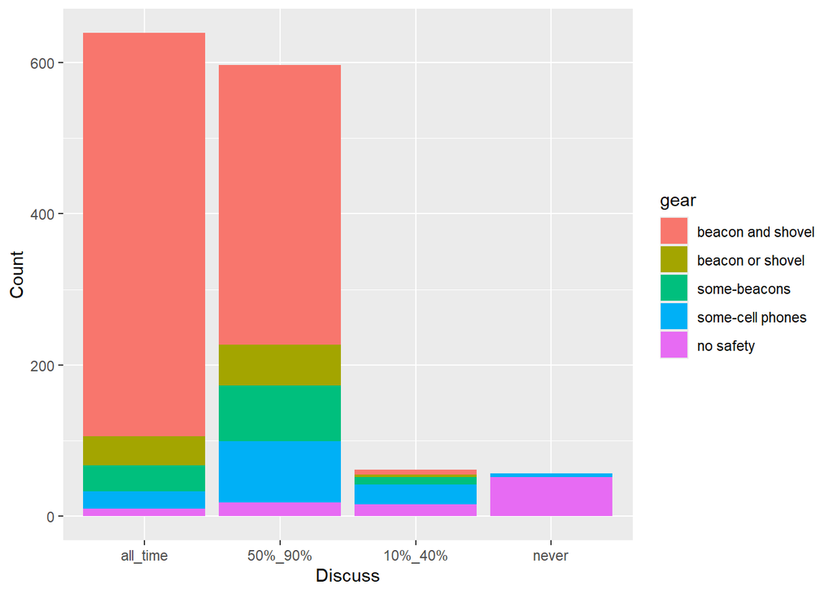

```r
# stacked bar chart
ggplot(AvalanchePrep, aes(x = discuss, fill = gear )) +
  geom_bar(position = "stack")+labs(x="Discuss",y="Count")
```

- Group one is the highest, and no one who take everything with them will never discuss with others.

## Grouped Bar chart

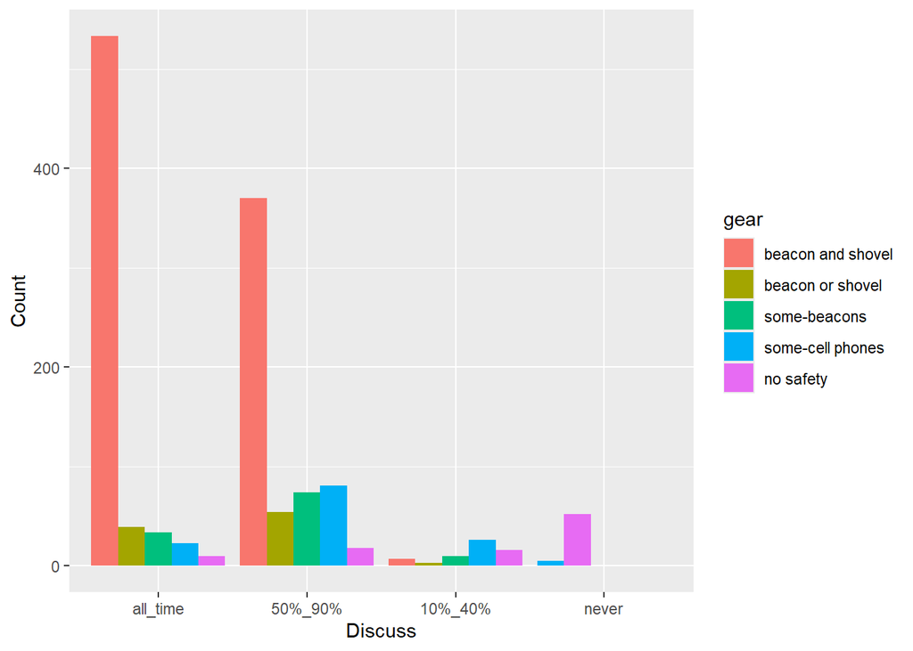

```r
# grouped bar plot preserving zero count bars
ggplot(AvalanchePrep, aes(x = discuss, fill =gear )) +
  geom_bar(position = position_dodge(preserve = "single"))+labs(x="Discuss", y="Count")
```

- More they discuss among each other more it is possible that they take all safty gears.

## Segmented Bar chart

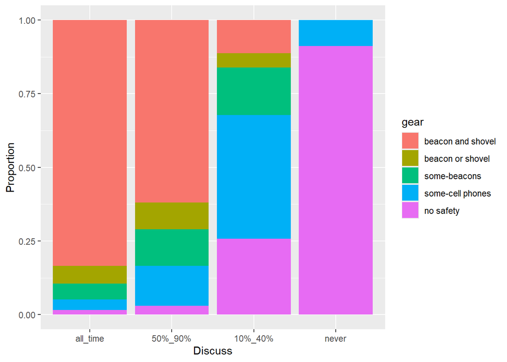

```r
# bar plot, with each bar representing 100%
ggplot(AvalanchePrep, aes(x = discuss , fill = gear)) +
geom_bar(position = "fill") +
  labs(y = "Proportion", x="Discuss")
```

This type of plot is particularly useful if the goal is to compare the percentage of a category in one variable across each level of another variable. You can see the dependence of the two variables. The more they talk to each other the less chances that will take poor safety gears.

## Scatter plot

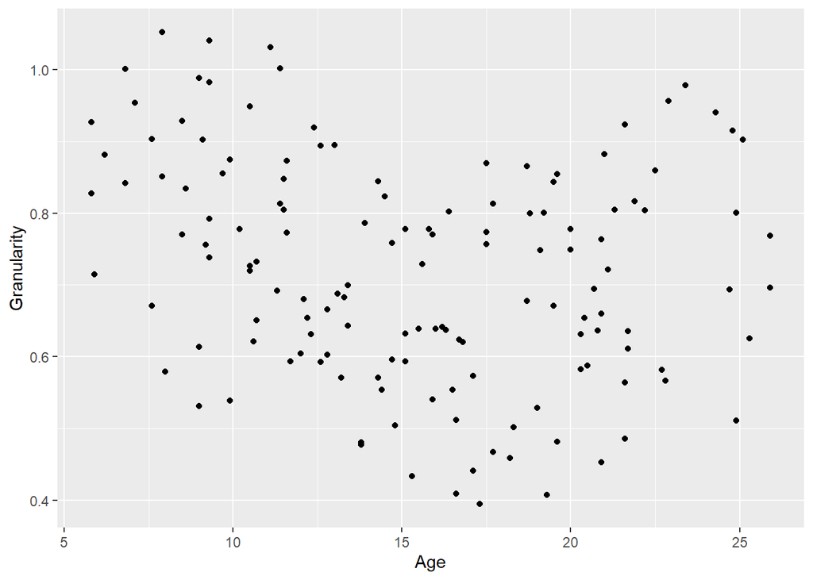

```r
ggplot(granularity, aes(x=age,y=gran))+geom_point()+labs(x="Age", y="Granularity")
```

## linear regression line

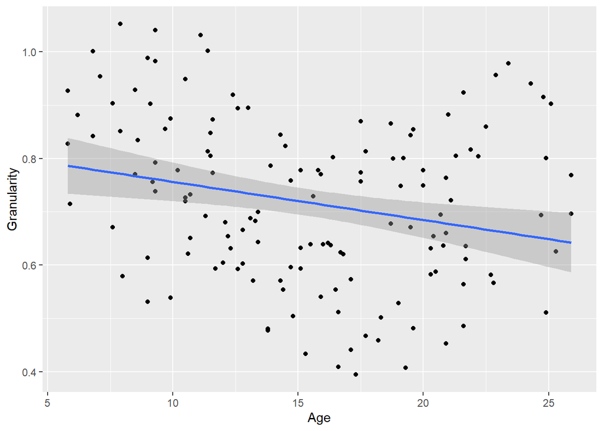

```r
ggplot(granularity, aes(x=age,y=gran))+geom_point()+geom_smooth(method = "lm")+labs(x="Age", y="Granularity")
```

## Add regression fit to your ggplot

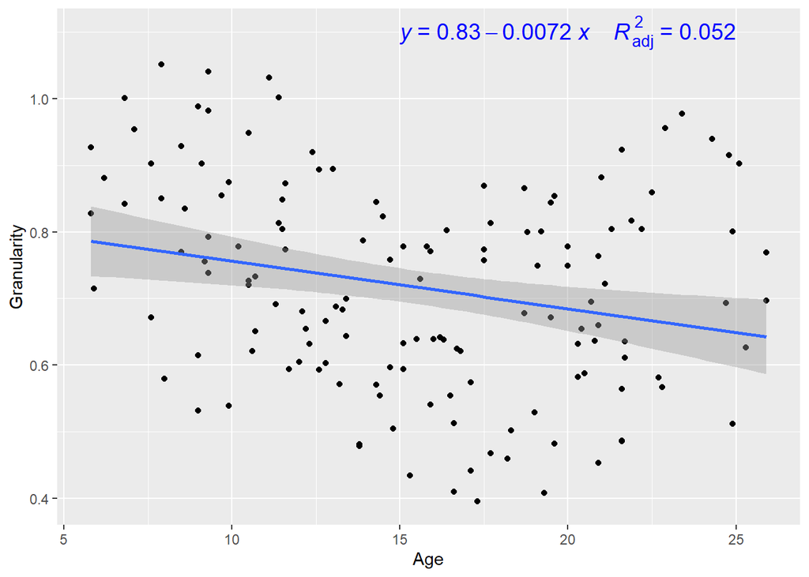

```r
ggplot(granularity, aes(x=age,y=gran))+geom_point()+geom_smooth(method = "lm")+stat_regline_equation(
    aes(label =  paste(..eq.label.., ..adj.rr.label.., sep = "~~~~")),label.x = 15,label.y=1.1,size=5 , color="blue") +labs(x="Age", y="Granularity")
```

## Smoothing Spline

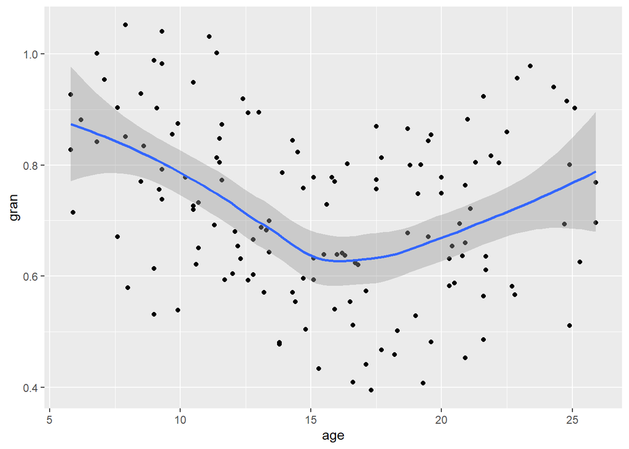

```r
ggplot(granularity, aes(x=age,y=gran))+geom_point()+geom_smooth()
```

## Check the formula of your polynomial fit

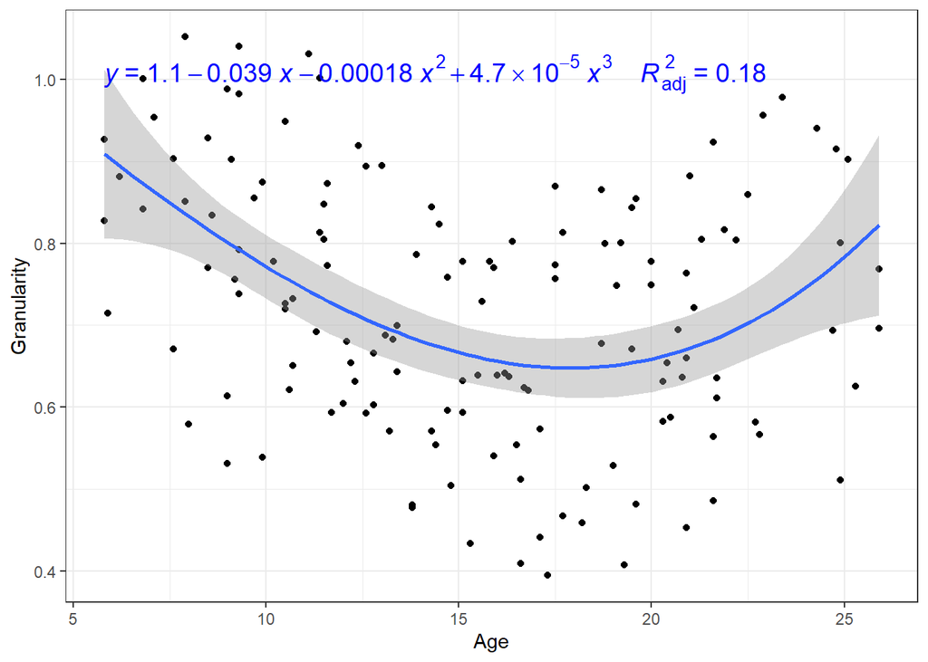

```r
formula <- y ~ poly(x, 3, raw = TRUE)
ggplot(granularity, aes(x=age,y=gran))+geom_point()+
  stat_smooth(method = "lm", formula = formula)+
  stat_regline_equation(aes(label =  paste(..eq.label.., ..adj.rr.label.., sep = "~~~~")),formula = formula, size=5,color="blue"  ) +  theme_bw()+labs(x="Age", y="Granularity")
```

## Line plot

Excerpt of the Gapminder data on life expectancy, GDP per capita, and population by country.

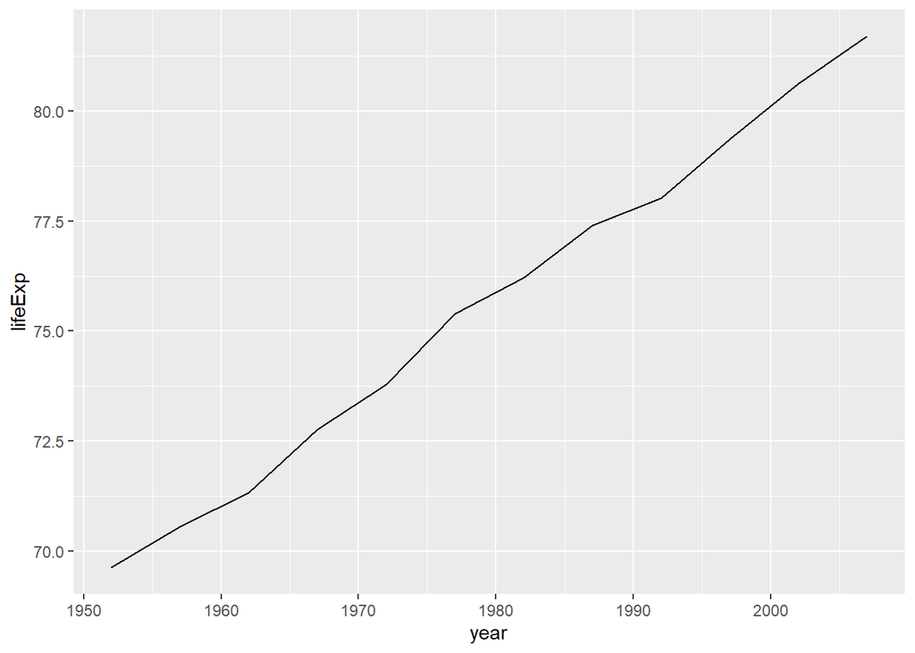

```r
data(gapminder, package="gapminder")
# Select Switzerland cases
plotdata <- filter(gapminder, country == "Switzerland")

# simple line plot
ggplot(plotdata, aes(x = year, y = lifeExp)) +
  geom_line()
```

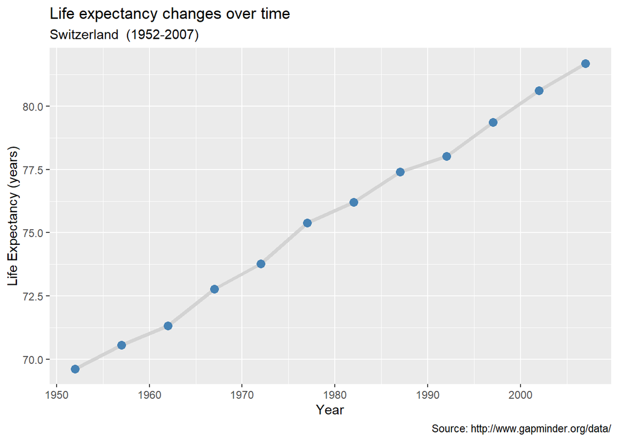

```r
# line plot with points
# and improved labeling
ggplot(plotdata, aes(x = year, y = lifeExp)) +
  geom_line(size = 1.5,
            color = "lightgrey") +
  geom_point(size = 3,
             color = "steelblue") +
  labs(y = "Life Expectancy (years)",
       x = "Year",
       title = "Life expectancy changes over time",
       subtitle = "Switzerland  (1952-2007)",
       caption = "Source: http://www.gapminder.org/data/")
```

## Grouped kernel density

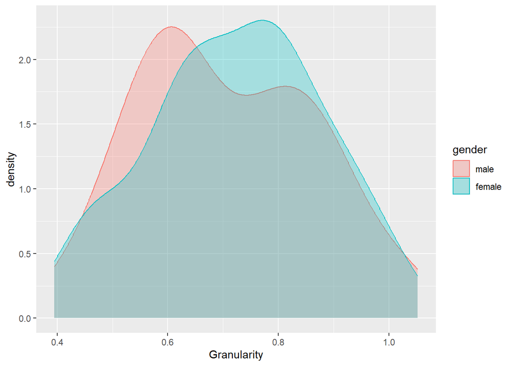

```r
ggplot(granularity,aes(x=gran,group=gender, color=gender, fill=gender))+geom_density(alpha=0.3)+labs(x="Granularity")
```

## Boxplot

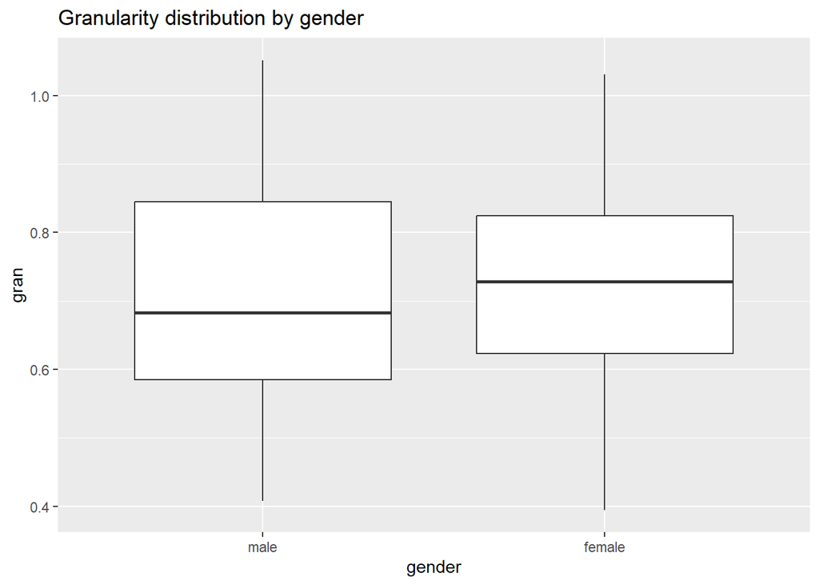

## Salary Data

```r
data(Salaries, package="carData")
```

### Grouped density plots

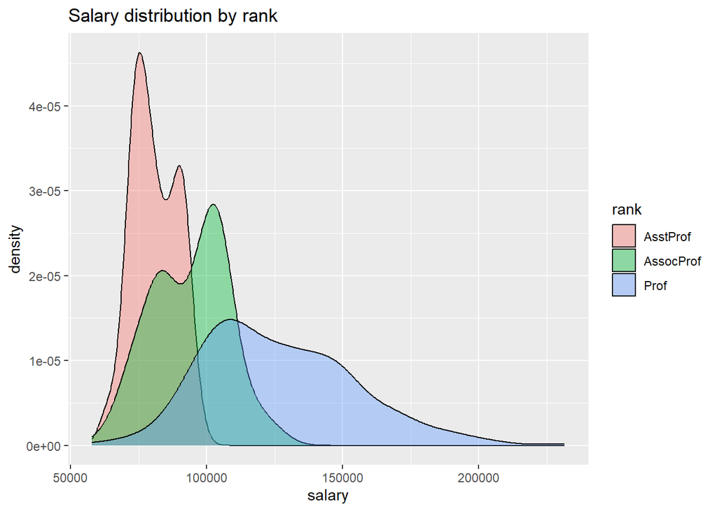

```r
# plot the distribution of salaries by rank using kernel density plots
ggplot(Salaries, aes(x = salary, fill = rank)) +
  geom_density(alpha = 0.4) +
  labs(title = "Salary distribution by rank")
```